# Customer Snapshots

### Contents

1. Background
2. Current Metrics
3. Hypothesis
4. Experimental Design
5. Statistical Analysis
6. Final Results
   - a) Overall
   - b) Tag split
   - c) Chat Origin
   - d) Tenure split

## Background

This initiative is the result of [user surveys](https://docs.google.com/spreadsheets/d/17hrHuZmNRnJeG9Pn24Im3Aa2lWFIJlbV0GcFX9L7zKI/edit?usp=sharing) on the performance of DASH26 which highlighted the importance for consolidated customer data.

For the vast majority of contacts processed by Customer Service, only a small fraction of the data available in Dash26 to first-level specialists is actually required to resolve a contact. This data is scattered across multiple modules and tabs, resulting in unnecessarily long loading times and thus longer contact resolution times.

Our goal is to remove unnecessary clicks, navigation and loading time by consolidating most of the necessary data into a “snapshot” of the customer. This should provide specialists with quicker access to the data they need and resolve the majority of contacts faster.

There are certain CS tags that may be more relevant to this feature including: 'sign_up','kyc_acceptance','card_delivery','card_activation/pin','login', 'confirmations/statements','dt/standing_order','ct/missing_ct','direct_debit', 'instant *ct* /missing_ct','instant_dt','savings','overdraft' since most of the information the agent needs for these sort of contacts will be in the snapshot feature.

For more info check out this confluence page [here](https://number26-jira.atlassian.net/wiki/spaces/CS/pages/2376532754/Customer+Snapshot+in+Dash26) .

### TLDR

Customer snapshots is a DASH26 module which shows the most accessed user information in just one view. This one module shows an aggregated view of multiple modules including customer information on; personal details, account, kyc, cards and transactions. We want to know if DASH26 improvements alone can improve handling times.

### Limitations

Handle time is made up of time chatting to a customer (Salesforce time), time investigating (DASH time) and wrap up.

Due to a lack of DASH tracking we are unable to track which agents actually use the new feature in the variant group of the split test. We also cannot track the total time actively in DASH. We are planning to add snowplow tracking in the near future.

## Current Metrics

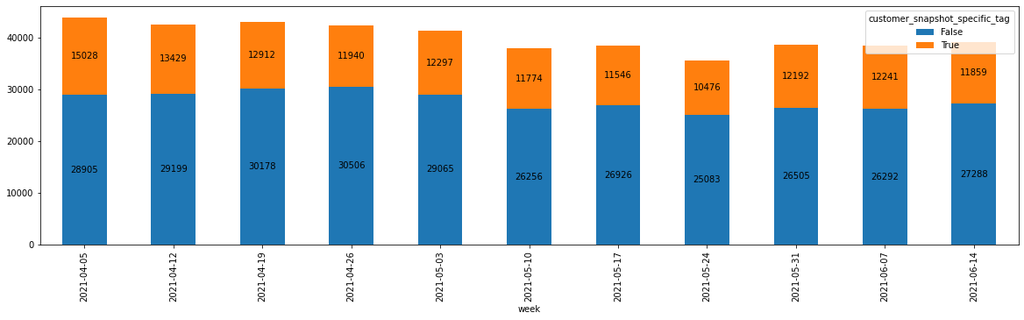

**Findings:** Volumes of 1st level chats can vary week on week. So we'll have to monitor how much volume we get as the A/B test is rolled out.

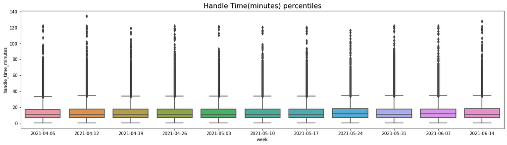

**Findings:** Percentiles for Handle Time minutes stays roughly constant over weeks. The median roughly sits around 10-12 minutes.

Note since we're dealing with a continuous variable(time) we can see quite a few outliers in the data which exceed past the 95th percentile.

## Hypothesis

Investigation time in Dash26 will be reduced with more easily accessible customer data via Customer Snapchats module thus impacting the overall 1st Level chat handling times.

H0 : there is no significant difference between 1st Level handling times

H1 : the 1st Level handling time of the test group is significantly less than the control group.

## Experimental Design

Specialists will be split based on language, company and tenure.

**A** group is the control; they will see the current version of DASH26.

**B** group is the variant; they will see the customer snapshots module in DASH26.

The A/B testing will be implemented from **2021-06-01** .

```
Specialist split in test/ dbt.sf_all_contacts from 2021-06-01 onwards
```

| Languages | test_group Company_Group | control | variant |
| --- | --- | --- | --- |
| DE | ECC | 16 | 17 |
|  | N26 | 4 | 6 |
| EN | ECC | 16 | 14 |
|  | N26 | 10 | 14 |
| ES | ECC | 4 | 4 |
|  | N26 | 6 | 4 |
| FR | ECC | 32 | 32 |
|  | N26 | 4 | 4 |
| IT | ECC | 7 | 9 |
|  | N26 | 9 | 6 |

```
Handle Time quantiles 3 months before split test
```

|  | specialist_tenure_months | handle_time_minutes |
| --- | --- | --- |
| count | 222263.000000 | 222263.000000 |
| mean | 16.989773 | 13.053347 |
| std | 7.351947 | 9.314718 |
| min | 0.000000 | 0.016600 |
| 25% | 11.000000 | 6.633300 |
| 50% | 17.000000 | 10.966600 |
| 75% | 23.000000 | 17.116600 |
| max | 52.000000 | 121.816600 |

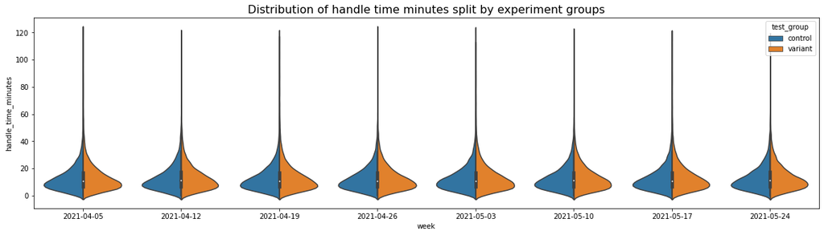

**Findings:** The distribution of 1st Level chat handle times seem to be right skewed.

We have to acknowledge that we do have many outliers in our distribution. This may make it difficult to compare means between A and B groups under the more common statistical tests for normal distributions.

## Statistical Analysis

**Independent variable** : Dash26 version (binary), agent split by language (categorical) ,company (categorical) and tenure(continuous).

**Dependant variable** : 1st Level handle time (continuous/ right skewed with many outlier)

**Statistical Test** : Mann-Whitney test (aka the Wilcoxon 2-sample Test) which compares the medians/rank sums from two populations and works when the Y variable is continuous. It is much more robust against outliers and heavy tail distributions.

**Type I Error** : Significance level, α = 0.05

**Type II Error** : β = 0.2

**Power** : The Mann Whitney test is underpowered in general so the chances of a false positive is quite low. This means if we find a significant result, we can be somewhat confident that it's significant/reflects reality.

(**Standard Power** : 1 – β = 1 – 0.2 = 0.8)

**Hypothesis** - one tailed test:

H0: the distributions of both samples are equal

H1: the distributions of the variant sample is lower than the control's (lower-tailed)

### Historical Data

```
Cumulative weekly Mann Whitney U test on historical handle time quantiles 3 months before split test
```

| test week | p_value all tags | p_value specific tags | result all tags | result specific tags |
| --- | --- | --- | --- | --- |
| 2021-04-05 | 0.371102 | 0.914840 | Samples have similar distributions (fail to reject H0) | Samples have similar distributions (fail to reject H0) |
| 2021-04-12 | 0.410134 | 0.662059 | Samples have similar distributions (fail to reject H0) | Samples have similar distributions (fail to reject H0) |
| 2021-04-19 | 0.408873 | 0.253303 | Samples have similar distributions (fail to reject H0) | Samples have similar distributions (fail to reject H0) |
| 2021-04-26 | 0.207521 | 0.073641 | Samples have similar distributions (fail to reject H0) | Samples have similar distributions (fail to reject H0) |
| 2021-05-03 | 0.321968 | 0.044448 | Samples have similar distributions (fail to reject H0) | Samples have similar distributions (fail to reject H0) |
| 2021-05-10 | 0.148223 | 0.059440 | Samples have similar distributions (fail to reject H0) | Samples have similar distributions (fail to reject H0) |
| 2021-05-17 | 0.079782 | 0.060264 | Samples have similar distributions (fail to reject H0) | Samples have similar distributions (fail to reject H0) |
| 2021-05-24 | 0.045410 | 0.044556 | Samples have similar distributions (fail to reject H0) | Samples have similar distributions (fail to reject H0) |

## Final Results

There was an incident in DASH26 on the first day of release, so we will exclude 2021-06-01 from results.

### Overall results

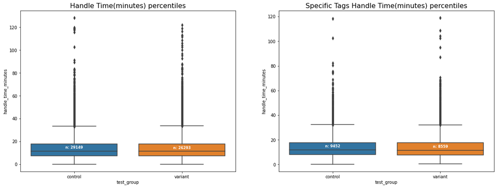

All tags

| level_1 Group (A/B) | 25% | 50% | 75% | count | max | mean | min | std |
| --- | --- | --- | --- | --- | --- | --- | --- | --- |
| A | 7.483300 | 11.700000 | 17.850000 | 29149.000000 | 128.166600 | 13.842549 | 0.016600 | 9.231598 |
| B | 7.433300 | 11.683300 | 17.983300 | 26293.000000 | 122.116600 | 13.994402 | 0.016600 | 9.634720 |

Specific tags

| level_1 Group (A/B) | 25% | 50% | 75% | count | max | mean | min | std |
| --- | --- | --- | --- | --- | --- | --- | --- | --- |
| A | 7.983300 | 11.900000 | 17.716600 | 9452.000000 | 118.183300 | 13.976494 | 0.116600 | 8.832562 |
| B | 7.683300 | 11.633300 | 17.516600 | 8559.000000 | 118.933300 | 13.923902 | 0.550000 | 9.318624 |

**Findings:** Visually there's not much difference in handle time overall or for our specific tags group between control and variant. From the final figures there is a 10-20 seconds decrease from the control's to variant's median in the specific tags group.

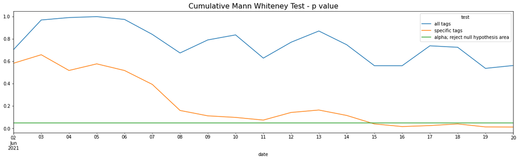

|  | date | test | p_value | result |
| --- | --- | --- | --- | --- |
| 16 | 2021-06-20 | all tags | 0.561663 | Samples have similar distributions (fail to reject H0) |
| 33 | 2021-06-20 | specific tags | 0.011621 | Variant time distribution is significantly different (less) (reject H0) |

**Findings:** Though the decrease is small for the specific tags group; ~2.24% decrease in the median and ~3.76% decrease in the 25th percentile, the result is significant using the Mann Whitney U test. The Snapshots Module feature does not impact the overall handle time distribution.

### Tag split

#### Specific Tags

We had the assumption that the Customer Snapshots module is more relavent to certain CS tags:

- card_activation/pin
- card_delivery
- confirmations/statements
- ct/missing_ct
- direct_debit
- dt/standing_order
- instant *ct* /missing_ct
- instant_dt
- kyc_acceptance
- login
- overdraft
- savings
- sign_up

```
Historicals
```

|  | date | control size | variant size | tag_name | p_value | result |
| --- | --- | --- | --- | --- | --- | --- |
| 587 | 2021-05-30 | 5375 | 5473 | login | 0.024031 | Variant time distribution is significantly lower than the control (reject H0) |
| 585 | 2021-05-30 | 4490 | 4244 | ct/missing_ct | 0.491693 | Samples have similar distributions (fail to reject H0) |
| 586 | 2021-05-30 | 3747 | 3522 | dt/standing_order | 0.620404 | Samples have similar distributions (fail to reject H0) |
| 591 | 2021-05-30 | 3674 | 3243 | card_delivery | 0.481917 | Samples have similar distributions (fail to reject H0) |
| 588 | 2021-05-30 | 3626 | 3525 | confirmations/statements | 0.372760 | Samples have similar distributions (fail to reject H0) |
| 592 | 2021-05-30 | 3340 | 3272 | card_activation/pin | 0.092337 | Samples have similar distributions (fail to reject H0) |
| 593 | 2021-05-30 | 1872 | 2179 | sign_up | 0.132497 | Samples have similar distributions (fail to reject H0) |
| 590 | 2021-05-30 | 1380 | 1307 | direct_debit | 0.077074 | Samples have similar distributions (fail to reject H0) |
| 589 | 2021-05-30 | 1206 | 1120 | kyc_acceptance | 0.000772 | Variant time distribution is significantly lower than the control (reject H0) |
| 594 | 2021-05-30 | 554 | 564 | overdraft | 0.706657 | Samples have similar distributions (fail to reject H0) |
| 595 | 2021-05-30 | 175 | 150 | savings | 0.390171 | Samples have similar distributions (fail to reject H0) |
| 597 | 2021-05-30 | 65 | 28 | instant_ct_/missing_ct | 0.274644 | Samples have similar distributions (fail to reject H0) |
| 596 | 2021-05-30 | 33 | 29 | instant_dt | 0.108504 | Samples have similar distributions (fail to reject H0) |

```
Experiment results
```

|  | date | control size | variant size | tag_name | p_value | result |
| --- | --- | --- | --- | --- | --- | --- |
| 184 | 2021-06-20 | 1775 | 1699 | login | 0.006667 | Variant time distribution is significantly lower than the control (reject H0) |
| 182 | 2021-06-20 | 1427 | 1329 | ct/missing_ct | 0.293408 | Samples have similar distributions (fail to reject H0) |
| 183 | 2021-06-20 | 1311 | 1185 | dt/standing_order | 0.529694 | Samples have similar distributions (fail to reject H0) |
| 185 | 2021-06-20 | 1081 | 1027 | card_activation/pin | 0.310018 | Samples have similar distributions (fail to reject H0) |
| 187 | 2021-06-20 | 1018 | 883 | confirmations/statements | 0.416511 | Samples have similar distributions (fail to reject H0) |
| 189 | 2021-06-20 | 995 | 752 | card_delivery | 0.477161 | Samples have similar distributions (fail to reject H0) |
| 186 | 2021-06-20 | 537 | 549 | sign_up | 0.004303 | Variant time distribution is significantly lower than the control (reject H0) |
| 190 | 2021-06-20 | 534 | 523 | direct_debit | 0.158421 | Samples have similar distributions (fail to reject H0) |
| 188 | 2021-06-20 | 441 | 282 | kyc_acceptance | 0.316693 | Samples have similar distributions (fail to reject H0) |
| 191 | 2021-06-20 | 276 | 256 | overdraft | 0.768990 | Samples have similar distributions (fail to reject H0) |
| 192 | 2021-06-20 | 32 | 46 | savings | 0.627436 | Samples have similar distributions (fail to reject H0) |
| 193 | 2021-06-20 | 20 | 21 | instant_ct_/missing_ct | 0.685281 | Samples have similar distributions (fail to reject H0) |
| 194 | 2021-06-20 | 5 | 7 | instant_dt | 0.208396 | Samples have similar distributions (fail to reject H0) |

Note: We have to acknowledge that we would have had to run the test for much longer if we wanted further breakdowns, we can already see the sample size is small for some of these tag names at the end of the list.

### Chat origin split

Assumption: Contacts from support center may benefit from the customer snapshots since generic customer information may be required for authentication.

```
Historicals
```

|  | date | control size | variant size | chat_origin | p_value | result |
| --- | --- | --- | --- | --- | --- | --- |
| 184 | 2021-05-30 | 31655 | 30656 | IOS | 0.986736 | Samples have similar distributions (fail to reject H0) |
| 185 | 2021-05-30 | 29950 | 28681 | ANDROID | 0.900919 | Samples have similar distributions (fail to reject H0) |
| 186 | 2021-05-30 | 17944 | 17740 | Support Center | 0.192580 | Samples have similar distributions (fail to reject H0) |
| 187 | 2021-05-30 | 13382 | 13060 | WEB | 0.192061 | Samples have similar distributions (fail to reject H0) |

```
Experiment results
```

|  | date | control size | variant size | chat_origin | p_value | result |
| --- | --- | --- | --- | --- | --- | --- |
| 67 | 2021-06-20 | 9927 | 8676 | ANDROID | 0.970891 | Samples have similar distributions (fail to reject H0) |
| 66 | 2021-06-20 | 9694 | 8810 | IOS | 0.301657 | Samples have similar distributions (fail to reject H0) |
| 64 | 2021-06-20 | 5558 | 5175 | Support Center | 0.000106 | Variant time distribution is significantly lower than the control (reject H0) |
| 65 | 2021-06-20 | 3970 | 3632 | WEB | 0.788160 | Samples have similar distributions (fail to reject H0) |

**Findings:** Looking at chat origin groups, there is sufficient evidence to prove a decrease in handle time distribution specifically for Support Center contacts.

### Tenure split

Assumption : newer agents don't have a set way of working and we may see the impact of the snapshot module more prevalent here.

```
Historicals
```

|  | date | control size | variant size | tenure_bins | p_value | result |
| --- | --- | --- | --- | --- | --- | --- |
| 187 | 2021-05-30 | 2701 | 1563 | (-0.001, 3.0] | 7.461551e-12 | Variant time distribution is significantly lower than the control (reject H0) |
| 184 | 2021-05-30 | 35230 | 27771 | (3.0, 15.0] | 1.000000e+00 | Samples have similar distributions (fail to reject H0) |
| 185 | 2021-05-30 | 29100 | 32388 | (15.0, 22.0] | 2.018498e-22 | Variant time distribution is significantly lower than the control (reject H0) |
| 186 | 2021-05-30 | 25900 | 28415 | (22.0, 52.0] | 1.000000e+00 | Samples have similar distributions (fail to reject H0) |

```
Experiment results
```

|  | date | control size | variant size | tenure_bins | p_value | result |
| --- | --- | --- | --- | --- | --- | --- |
| 67 | 2021-06-20 | 1381 | 879 | (-0.001, 3.0] | 9.545698e-08 | Variant time distribution is significantly lower than the control (reject H0) |
| 64 | 2021-06-20 | 9353 | 7574 | (3.0, 15.0] | 9.985274e-01 | Samples have similar distributions (fail to reject H0) |
| 66 | 2021-06-20 | 8432 | 9055 | (15.0, 22.0] | 1.020336e-05 | Variant time distribution is significantly lower than the control (reject H0) |
| 65 | 2021-06-20 | 9983 | 8785 | (22.0, 52.0] | 9.999983e-01 | Samples have similar distributions (fail to reject H0) |

**Findings:** Looking at tenure groups, there doesn't seem to be sufficient evidence to prove a decrease in handle time distribution. Results are inconclusive.